# Image classification on CIFAR-10

```python
learner.export('resnet50_3.pkl')
```

Guardem només els paràmetres del model:

```python
learner.save('res50phase-3')
```

```
Path('models/res50phase-3.pth')
```

Instanciem un learner canviant la loss function per utilitzar amb la tècnica de MixUp

```python
learner = vision_learner(dls3, resnet50,
                      metrics=[accuracy,error_rate],
                      loss_func=LabelSmoothingCrossEntropy(),
                      cbs=MixUp()).to_fp16()
```

Descongelem el model preentrenat i carreguem paràmetres de la xarxa preentrenada previament.

```python
learner.unfreeze()
learner.load('/content/drive/MyDrive/res50phase-3')
learner.unfreeze()
```

```
SuggestedLRs(valley=0.00013182566908653826)
```

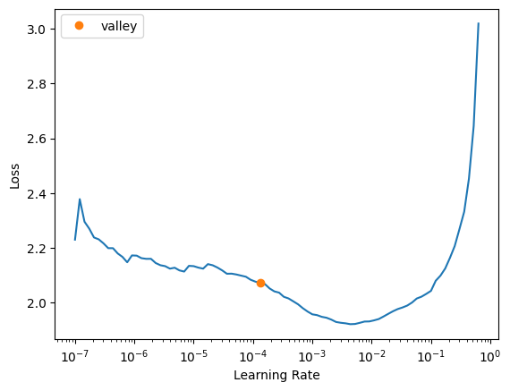

```python
learner.lr_find()
```

Entrenem la xarxa durant 50 èpoques.

```python
learner.fit_one_cycle(50, lr_max=slice(1e-6,3e-3))
```

| epoch | train_loss | valid_loss | accuracy | error_rate | time |
| --- | --- | --- | --- | --- | --- |
| 0 | 1.290378 | 0.815519 | 0.892700 | 0.107300 | 01:44 |
| 1 | 1.249276 | 0.795770 | 0.891300 | 0.108700 | 01:44 |
| 2 | 1.231070 | 0.775109 | 0.895700 | 0.104300 | 01:46 |
| 3 | 1.211611 | 0.763874 | 0.897300 | 0.102700 | 01:44 |
| 4 | 1.199017 | 0.758714 | 0.899300 | 0.100700 | 01:45 |
| 5 | 1.196473 | 0.747864 | 0.896800 | 0.103200 | 01:46 |
| 6 | 1.199042 | 0.755941 | 0.902400 | 0.097600 | 01:44 |
| 7 | 1.181431 | 0.742930 | 0.905300 | 0.094700 | 01:46 |
| 8 | 1.170266 | 0.740049 | 0.909000 | 0.091000 | 01:46 |
| 9 | 1.169651 | 0.727839 | 0.909500 | 0.090500 | 01:45 |
| 10 | 1.153872 | 0.724448 | 0.910600 | 0.089400 | 01:46 |
| 11 | 1.129743 | 0.728619 | 0.909100 | 0.090900 | 01:44 |
| 12 | 1.128913 | 0.720773 | 0.911600 | 0.088400 | 01:44 |
| 13 | 1.109213 | 0.715489 | 0.910900 | 0.089100 | 01:46 |
| 14 | 1.098980 | 0.711065 | 0.916000 | 0.084000 | 01:45 |
| 15 | 1.102323 | 0.715437 | 0.916300 | 0.083700 | 01:44 |
| 16 | 1.090921 | 0.704586 | 0.917400 | 0.082600 | 01:46 |
| 17 | 1.082021 | 0.705905 | 0.920600 | 0.079400 | 01:43 |
| 18 | 1.074274 | 0.705608 | 0.918500 | 0.081500 | 01:44 |
| 19 | 1.079268 | 0.696632 | 0.921800 | 0.078200 | 01:46 |
| 20 | 1.060478 | 0.702522 | 0.918100 | 0.081900 | 01:44 |
| 21 | 1.068667 | 0.696316 | 0.924400 | 0.075600 | 01:45 |
| 22 | 1.049742 | 0.695419 | 0.923300 | 0.076700 | 01:46 |
| 23 | 1.049992 | 0.693208 | 0.924200 | 0.075800 | 01:44 |
| 24 | 1.045828 | 0.689457 | 0.925900 | 0.074100 | 01:44 |
| 25 | 1.048791 | 0.702715 | 0.923100 | 0.076900 | 01:44 |
| 26 | 1.036826 | 0.697594 | 0.924400 | 0.075600 | 01:44 |
| 27 | 1.037868 | 0.688961 | 0.925700 | 0.074300 | 01:43 |
| 28 | 1.029137 | 0.694271 | 0.925600 | 0.074400 | 01:44 |
| 29 | 1.025911 | 0.687641 | 0.926900 | 0.073100 | 01:46 |
| 30 | 1.023443 | 0.685972 | 0.928600 | 0.071400 | 01:44 |
| 31 | 1.019069 | 0.690292 | 0.927200 | 0.072800 | 01:44 |
| 32 | 1.024539 | 0.685348 | 0.929000 | 0.071000 | 01:45 |
| 33 | 1.013842 | 0.688120 | 0.926300 | 0.073700 | 01:43 |
| 34 | 1.005895 | 0.680830 | 0.929600 | 0.070400 | 01:43 |
| 35 | 1.011403 | 0.682069 | 0.930500 | 0.069500 | 01:43 |
| 36 | 1.013764 | 0.683684 | 0.929300 | 0.070700 | 01:44 |
| 37 | 1.005077 | 0.681588 | 0.932000 | 0.068000 | 01:43 |
| 38 | 1.006112 | 0.679114 | 0.930600 | 0.069400 | 01:43 |
| 39 | 1.003976 | 0.680411 | 0.930300 | 0.069700 | 01:43 |
| 40 | 1.008793 | 0.677602 | 0.931800 | 0.068200 | 01:45 |
| 41 | 0.992394 | 0.674038 | 0.933700 | 0.066300 | 01:43 |
| 42 | 1.006041 | 0.674834 | 0.933400 | 0.066600 | 01:43 |
| 43 | 0.996582 | 0.674807 | 0.933900 | 0.066100 | 01:43 |
| 44 | 0.991097 | 0.677874 | 0.932800 | 0.067200 | 01:45 |
| 45 | 1.001115 | 0.676386 | 0.933500 | 0.066500 | 01:44 |
| 46 | 0.996189 | 0.673824 | 0.934100 | 0.065900 | 01:44 |
| 47 | 1.003209 | 0.675029 | 0.934200 | 0.065800 | 01:45 |
| 48 | 1.002475 | 0.675752 | 0.933900 | 0.066100 | 01:43 |
| 49 | 0.993714 | 0.674609 | 0.933700 | 0.066300 | 01:43 |

En aquest cas els temps d'entrenament no han augmentat, tot i emprar una xarxa més profunda. Aconseguim una *accuracy* del 93.4%, superior a l'aconseguida amb la resnet34.

```python
learner.export('resnet50_final.pkl')
```

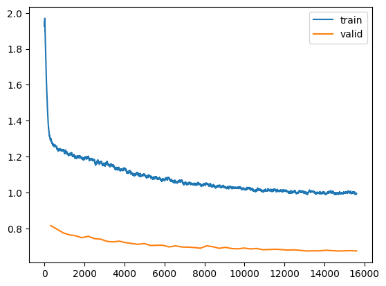

```python
learner.recorder.plot_loss()
```

El comportament de la loss d'entrenament i validació és similar a l'experiment anterior.

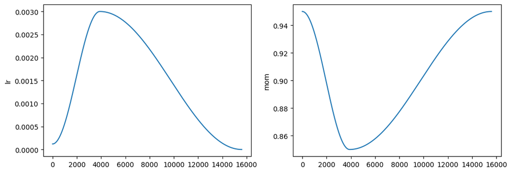

```python
learner.recorder.plot_sched()
```

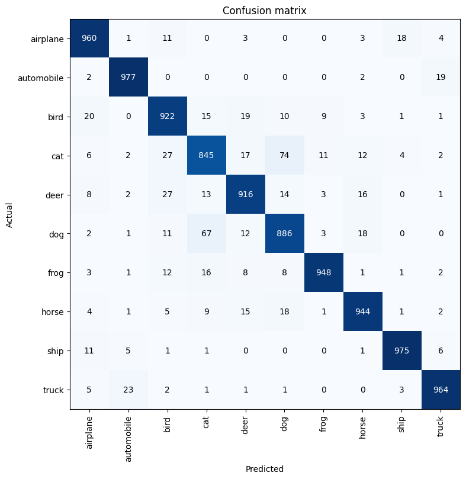

```python
interp = ClassificationInterpretation.from_learner(learner)
interp.plot_confusion_matrix(figsize=(8,8))
```

Es pot veure com el percentatge d’imatges correctament classificades és superior a les de l’experiment anterior en totes les classes, excepte la de granota que disminueix lleugerament i la de cavall, que manté els 944 encerts.

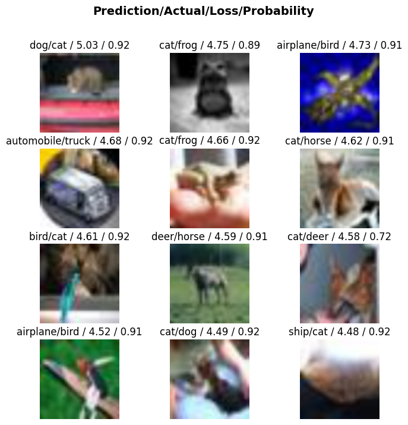

```python
interp.plot_top_losses(12, nrows=4, figsize=(8, 8))
```

# Exportació de la solució

A l'haver obtingut millor accuracy, utilitzarem el model entrenat amb resnet50 per fer les prediccions. Carreguem el model:

```python
learner = load_learner('/content/resnet50_final.pkl')
```

Descomprimim les imatges no etiquetades a l'arrel del notebook.

```python
!unzip '/content/drive/MyDrive/CIFAR/test_unlabelled' -d '/content'
```

```python
path = Path('/content')
```

Creem una llista amb els paths de cada imatge no etiquetada.

```python
test_files = [fn for fn in sorted((path/'test_unlabelled').glob('**/*')) if fn.is_file()]
```

Creem el dataloader de les imatges no etiquetades.

```python
test_dl = learner.dls.test_dl(test_files)
```

Preedim la classe de les imatges en batchs de 128.

```python
preds, _ = learner.get_preds(dl=test_dl)
```

Creem una llista amb el número que codifica la classe de cada imatge, accedint al valor del tensor obtingut.

```python
predictions = [str(preds[i].argmax().item()) for i in range(10000)]
```

```python
len(predictions)
```

```
10000
```

```python
predictions[:10]
```

```
['0', '4', '3', '3', '1', '3', '9', '0', '3', '2']
```

Exportació a arxiu csv, cada classe és una row.

```python
text = "\n".join(predictions)
with open('solution.csv', 'w') as f:
    f.write(text)
```